# Programming Exercise 3: Multi-class Classification and Neural Networks

## Part I

In this exercise, you will implement one-vs-all logistic regression and neural networks to recognize hand-written digits.

For this exercise, you will use logistic regression and neural networks to recognize handwritten digits (from 0 to 9). Automated handwritten digit recognition is widely used today - from recognizing zip codes (postal codes) on mail envelopes to recognizing amounts written on bank checks.

In the first part of the exercise, you will extend your previous implemen- tion of logistic regression and apply it to one-vs-all classification.

You are given a data set in ex3data1.mat that contains 5000 training exam- ples of handwritten digits.

### Part 1: Loading and Visualizing Data

```r
# remove all list
rm(list = ls())
library(R.matlab)
```

```r
library(ggplot2)
data3 <- readMat("ex3data1.mat")

str(data3)
```

```
## List of 2
##  $ X: num [1:5000, 1:400] 0 0 0 0 0 0 0 0 0 0 ...
##  $ y: num [1:5000, 1] 10 10 10 10 10 10 10 10 10 10 ...
##  - attr(*, "header")=List of 3
##   ..$ description: chr "MATLAB 5.0 MAT-file, Platform: GLNXA64, Created on: Sun Oct 16 13:09:09 2011                                                "
##   ..$ version    : chr "5"
##   ..$ endian     : chr "little"
```

#### Visualize data

There are 5000 training examples in ex3data1.mat, where each training example is a 20 pixel by 20 pixel grayscale image of the digit. Each pixel is represented by a floating point number indicating the grayscale intensity at that location. **The 20 by 20 grid of pixels is “unrolled” into a 400-dimensional vector.** Each of these training examples becomes a single row in our data matrix X. This gives us a 5000 by 400 matrix X where every row is a training example for a handwritten digit image.

To graph it, first select a random number of rows to plot. Then roll back each row in matrix.

```r
sample<-sample(1:nrow(data3$X), 25, replace=F)
```

Keep the same sample for check afterwards.

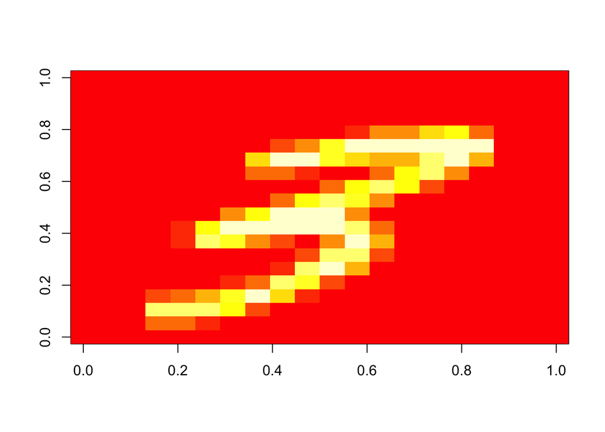

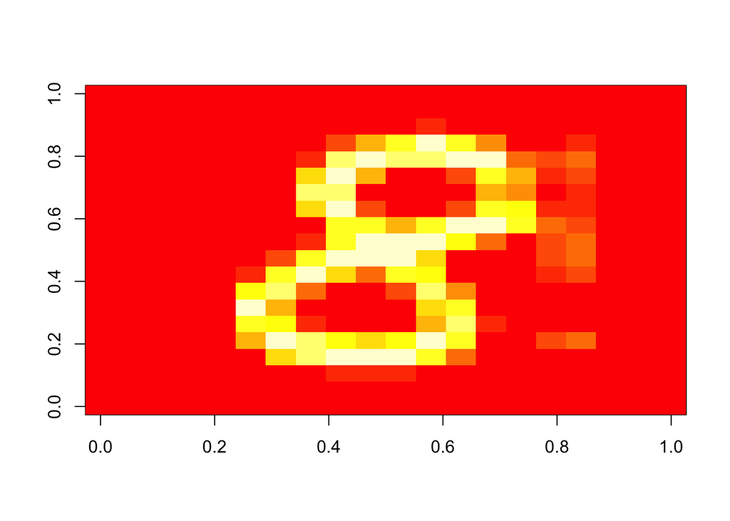

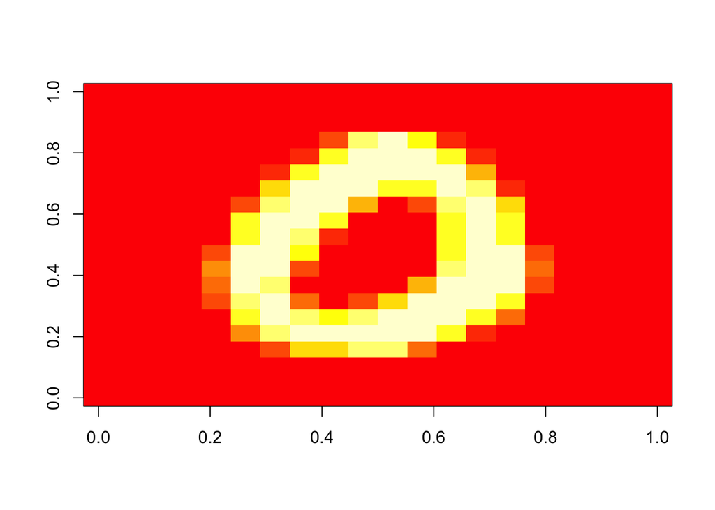

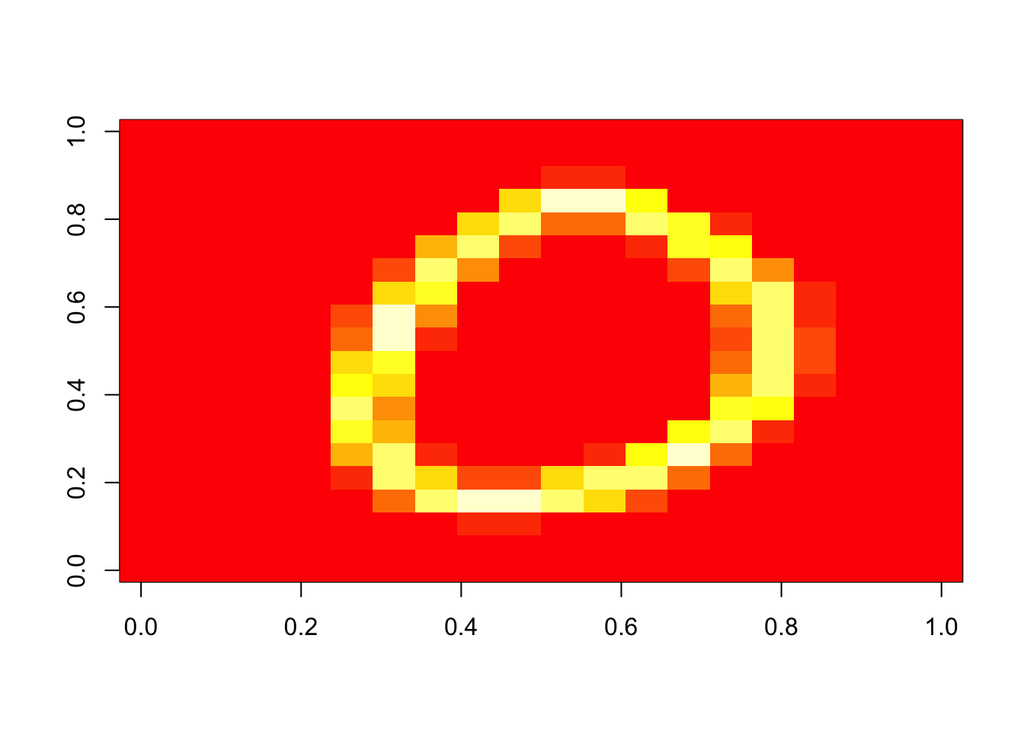

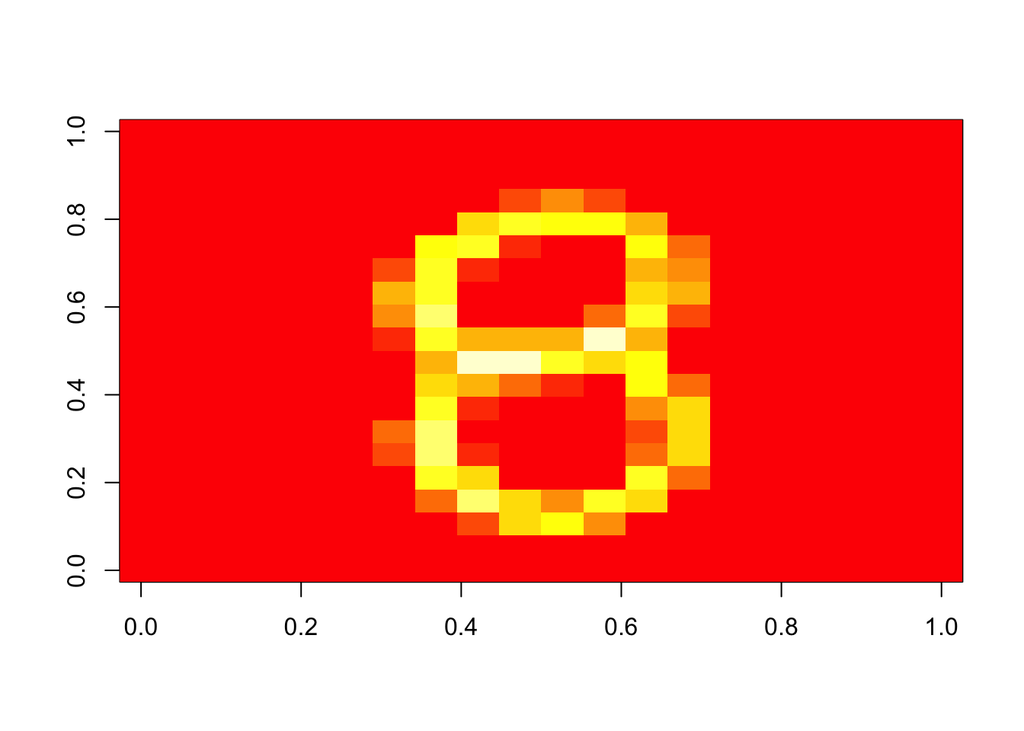

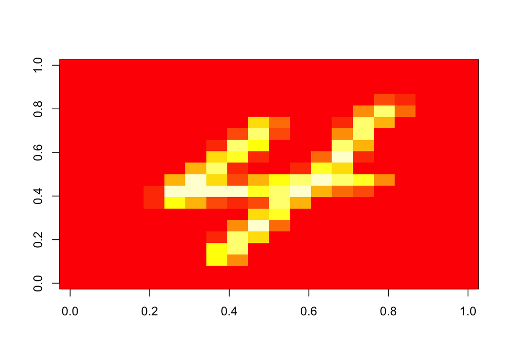

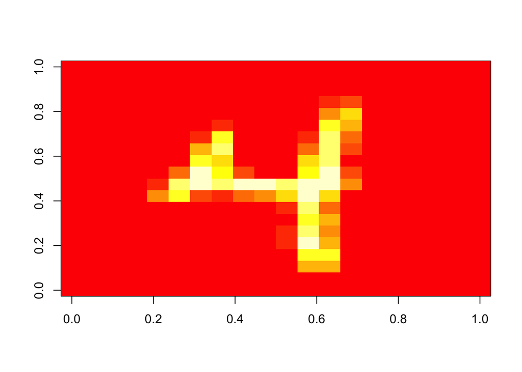

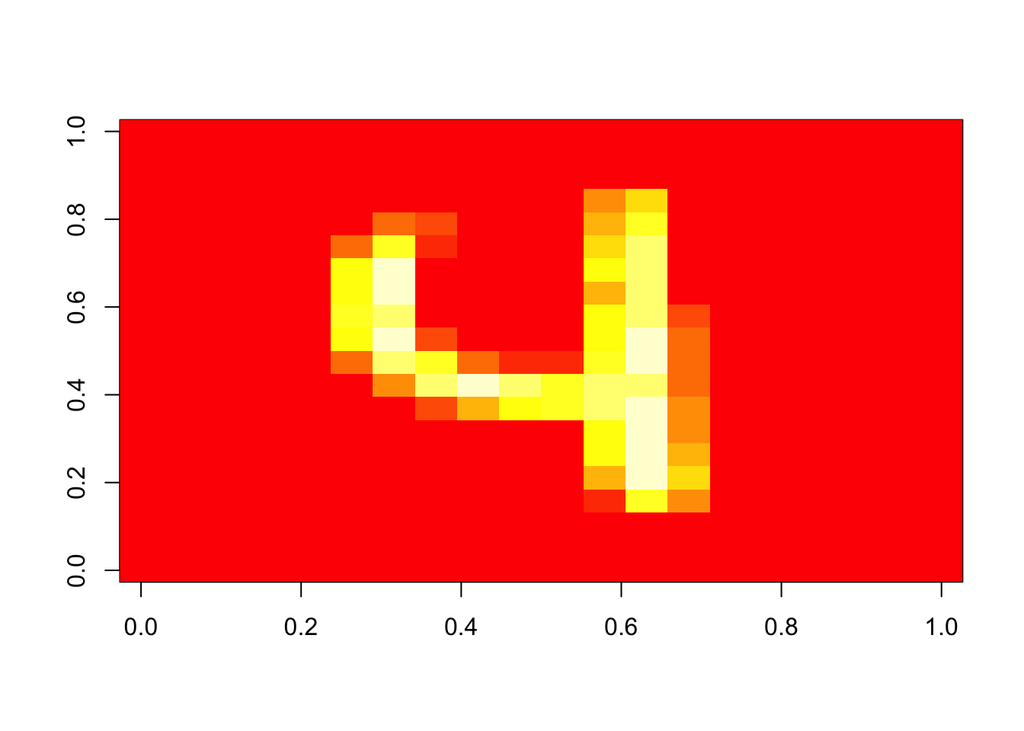

[figure not shown]

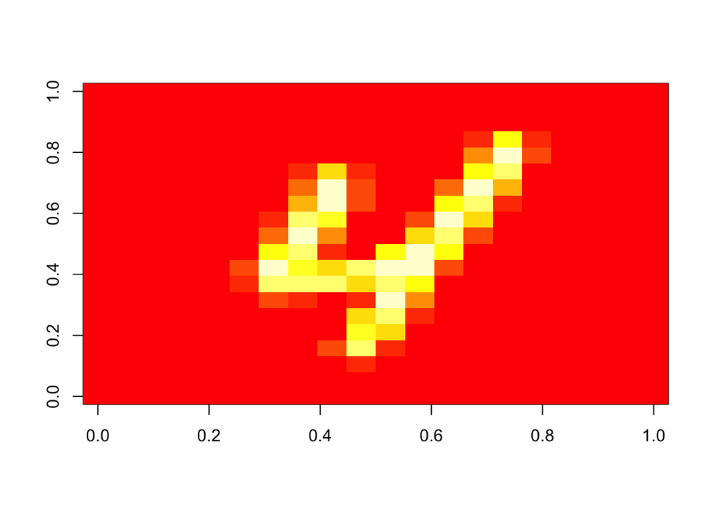

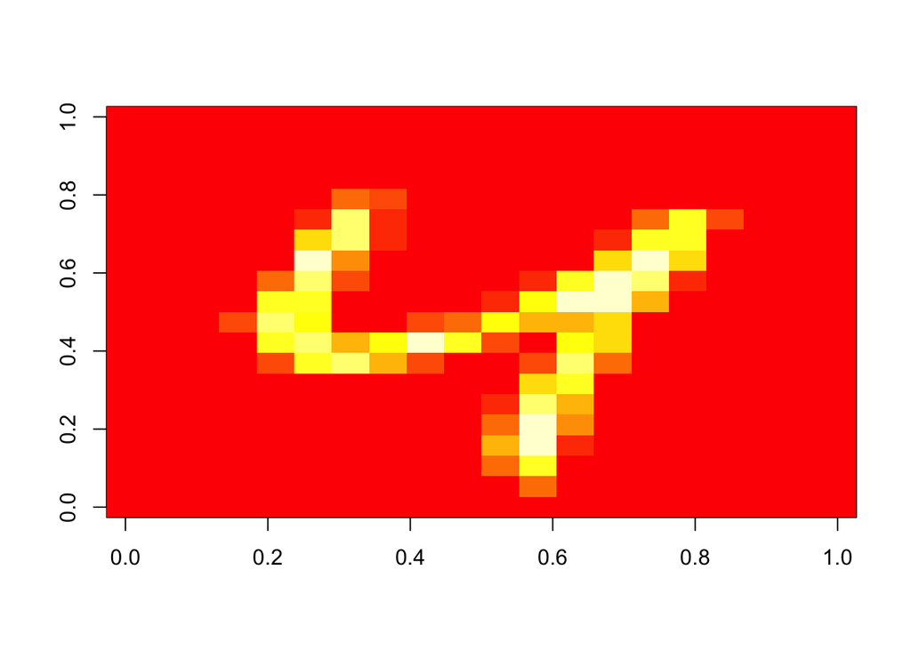

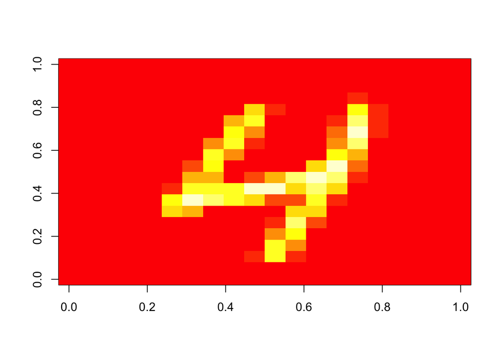

[13 more figures not shown]

```r
par(mfrow = c(1, 1))
# par(mfrow = c(5, 5))
for(i in sample){
  t<-matrix(data3$X[i,],20,20,byrow=T)
  t1<-t[,20:1]
  image(t1)
}
```

### Part2: Vectorizing Logistic Regression

Define sigmoid function:

```r
# sigmoid function
sigmoid<-function(z){
  # %SIGMOID Compute sigmoid functoon
  # %   J = SIGMOID(z) computes the sigmoid of z.
  enez = exp(-z);
  g = 1/(1+enez);
  return(g)
}
```

#### Cost functions

```r
costFunctionReg<-function(theta,X,y, lambda){
  # %COSTFUNCTIONREG Compute cost and gradient for logistic regression with regularization
  # %   J = COSTFUNCTIONREG(theta, X, y, lambda) computes the cost of using
  # %   theta as the parameter for regularized logistic regression and the
  # %   gradient of the cost w.r.t. to the parameters.

  #  number of training examples
  m<-length(y)
  grad<-array(data=0,dim=c(dim(theta)))

  yhat<-sigmoid(X%*%theta)
  # % theta1 to thetan
  thetas<-theta[2:nrow(theta),]
  reg = (lambda/(2*m))*sum(thetas^2)
  J<-(1/m)*sum(-y*log(yhat)-(1-y)*log(1-yhat))+reg
  temp=theta
  grad = (1 /m)*(t(X)%*%(yhat-y))+(lambda/(m))*temp;
  results<- list("J"=J,"grad"=grad)
  return(results)
}
```

#### One-vs-all Classification

In this part of the exercise, you will implement one-vs-all classification by training multiple regularized logistic regression classifiers, one for each of the K classes in our dataset First, define cost and grad functions to plug into `optim` function:

```r
# define fr and grr seperately from costFunction
fr_cost<-function(theta_v,X,y,lambda){
  theta<-as.matrix(theta_v)

  # convert X to matrix for matrix cal in functions
  X<-as.matrix(X)

  cf.rs<-costFunctionReg(theta, X, y,lambda);
  cost<-cf.rs$J
  return(cost)
}
grr_grad<-function(theta_v,X,y,lambda){
  theta<-as.matrix(theta_v)

  X<-as.matrix(X)
  cf.rs<-costFunctionReg(theta, X, y,lambda);
  grad<-cf.rs$grad
  return(grad)
}
```

```r
oneVsAll<-function(X, y, num_labels, lambda){
  # %ONEVSALL trains multiple logistic regression classifiers and returns all
  # %the classifiers in a matrix all_theta, where the i-th row of all_theta
  # %corresponds to the classifier for label i
  # %   [all_theta] = ONEVSALL(X, y, num_labels, lambda) trains num_labels
  # %   logisitc regression classifiers and returns each of these classifiers
  # %   in a matrix all_theta, where the i-th row of all_theta corresponds
  # %   to the classifier for label i

  # % Some useful variables
  m <- nrow(y)
  n<-ncol(X)
  # % Add intercept term to X
  ones<-array(data=1,dim=c(m,1))
  X<-cbind(ones,X)
  # Initialize fitting parameters
  initial_theta = array(data=0,dim=c(ncol(X),1))
  for(c in 1:num_labels){
    # % Optimize
    op<-optim(par=initial_theta, fn=fr_cost, gr=grr_grad, X=X,y==c,lambda=lambda,
              method = "BFGS",control = list("maxit"=50))
    theta<-op$par
    if(c==1){
      all_theta<-t(theta)
    }else{all_theta<-rbind(all_theta,t(theta))}
  }
  return(all_theta)
}


# function [all_theta] = oneVsAll(X, y, num_labels, lambda)



# for c = 1:num_labels
#   % Set Initial theta
#   initial_theta = zeros(n + 1, 1);
#
#   % Set options for fminunc
#   options = optimset('GradObj', 'on', 'MaxIter', 50);
#
#   % Run fmincg to obtain the optimal theta
#   % This function will return theta and the cost
#   [theta] = ...
#      fmincg (@(t)(lrCostFunction(t, X, (y == c), lambda)), ...
#              initial_theta, options);
#   all_theta(c,:) = theta';
# end;
```

Set up and use

```r
num_labels = 10
lambda = 0.1
op<-oneVsAll(data3$X, data3$y, num_labels, lambda)
```

Predict based on $\theta_s$ from training

```r
predictOneVsAll<-function(all_theta, X){
  # %PREDICT Predict the label for a trained one-vs-all classifier. The labels
  # %are in the range 1..K, where K = size(all_theta, 1).
  # %  p = PREDICTONEVSALL(all_theta, X) will return a vector of predictions
  # %  for each example in the matrix X. Note that X contains the examples in
  # %  rows. all_theta is a matrix where the i-th row is a trained logistic
  # %  regression theta vector for the i-th class. You should set p to a vector
  # %  of values from 1..K (e.g., p = [1; 3; 1; 2] predicts classes 1, 3, 1, 2
  # %  for 4 examples)

  m = nrow(X)
  num_labels = nrow(all_theta)

  # % Add intercept term to X
  ones<-array(data=1,dim=c(m,1))
  X<-cbind(ones,X)
  # z<-sweep(X,MARGIN=2,as.vector(all_theta),`*`)
  yhat = sigmoid(X%*%t(all_theta))
  # % prediction is the max position of each row
  max<-apply(yhat,1,max)
  p<-max.col(yhat, 'first')
  return(p)
}
# function p = predictOneVsAll(all_theta, X)
# %PREDICT Predict the label for a trained one-vs-all classifier. The labels
# %are in the range 1..K, where K = size(all_theta, 1).
# %  p = PREDICTONEVSALL(all_theta, X) will return a vector of predictions
# %  for each example in the matrix X. Note that X contains the examples in
# %  rows. all_theta is a matrix where the i-th row is a trained logistic
# %  regression theta vector for the i-th class. You should set p to a vector
# %  of values from 1..K (e.g., p = [1; 3; 1; 2] predicts classes 1, 3, 1, 2
# %  for 4 examples)
#
# m = size(X, 1);
# num_labels = size(all_theta, 1);
#
# % You need to return the following variables correctly
# p = zeros(size(X, 1), 1);
#
# % Add ones to the X data matrix
# X = [ones(m, 1) X];
#
#
# yhat = sigmoid(X*all_theta');
```

predict:

```r
pred <-predictOneVsAll(op, data3$X)
```

Training Set Accuracy (in percent):

```r
mean(pred == data3$y) * 100
```

```
## [1] 93.2
```

## Part II:

In R, `mlogit` from package mlogit and `multinom` (built based on nnet) from package nnet solve Multinomial logit models. In other words, they are not directly ready to process Multi-class Classification.

In this exercise, you will implement the neural networks from R packages and apply it to the task of hand-written digit recognition.

Our neural network has 3 layers – an input layer, a hidden layer and an output layer. Since the images are of size 20 × 20, this gives us 400 input layer units. The parameters have dimensions that are sized for a neural network with 25 units in the second layer and 10 output units (corresponding to the 10 digit classes).

```r
# reform y as matrix of n*10, with 0/1 indicating which number it is
y<-array(0,dim=c(nrow(data3$y),10))
for (i in 1:nrow(data3$y)){
  val<-data3$y[i]
  y[i,val]<-1
}
```

Now implement neural networks model using `nnet` from nnet library: Note that # weights = $\sum{s_{j+1}*(s_j+1)}=25*401+10*26$

```r
library(nnet)
nn1 <- nnet(data3$X, y, size = 25, rang = 0.1,MaxNWts=20000 ,decay = 5e-5, maxit = 200)
```

Check on the accuracy of results:

```r
pred<-predict(nn1, data3$X)
ypred<-max.col(pred)
test.cl <- function(true, pred) {
  true <- (true)
  cres <- (pred)
  table(true, cres)
}
tst_tbl<-test.cl(data3$y, ypred)
tst_tbl
```

```
##     cres
## true   1   2   3   4   5   6   7   8   9  10
##   1  477   1   7   3   0   1   4   4   3   0
##   2    1 430  11  12   0   5  12  21   1   7
##   3    1  13 448   3   4   2   6  18   3   2
##   4    2   1   0 483   0   1   0   5   8   0
##   5    1   3   6   7 461   6   1   9   3   3
##   6    0   3   0   3   3 476   0   9   1   5
##   7    4   4  13   6   2   0 462   3   5   1
##   8    3   4  13   9   3   1   0 458   7   2
##   9    1   1  11  28   0   0   9  13 435   2
##   10   0   3   4   0   3   2   2   8   1 477
```

Training Set Accuracy (in percent):

```r
mean(ypred == data3$y) * 100
```

```
## [1] 92.14
```